# Informal settlements of Syrian refugees in Lebanon

- Data was downloaded from https://data.humdata.org/dataset/informal-settlements-refugees-living-in-informal-settlements
- From the link: "In Lebanon Syrian refugees are scattered all over the country, mostly living in the cities and villages with host communities renting or occupying abandoned or unfinished buildings, however over 30% of the refugees are living in tents in Informal Settlements. Informal Settlements are collections of tents (not more than 20 tents)."

# Variable definitions

- **PCode**: Officially assigned PCode. This is unique to every IS. It holds the CAS (Central Administration of Statistics) Number, the IS code and the sequemtial number of the IS. Use this code to refer to the IS. Medair assigns PCodes. This code should be used as a reference to any documentation citing an informal settlement.
- **PCode Name**: P-Code based naming of the informal settlement, based on the name of the cadastral and and the site's 3 digit sequential number. This is the official name of the settlement.
- **Governorate**: Governorate
- **District**: District
- **Cadastral Name**: Name of the Cadaster where the settlement is located
- **Local Name**: Local Name of the Settlement according to NGOs working there or residents
- **Latitude**: Latitude
- **Longitude**: Longitude
- **Shelter Type**: Informal settlement
- **Status**: Active, Less than 4,Inactive, Not Willing or Erroneous
- **Number of Tents**: Number of tents in the settlements verified by physical observation
- **Number of Individuals**: Number of individuals living in Tents, verified by asking each tent's residents how many people sleep there each night.
- **Date of the current update**: What date the update was taken - accuracy of the data is only for this particular date as settlements change frequently.
- **Updated By**: Partner who undertook the update, 'Other' if from a secondary data source and not yet verified
- **Updated On**: "Sweep" in which the site was updated
- **Discovery Date**: Calculated by running a query on all IAMP data from IAMP 1 to current IAMP to determine the first available date of update
- **Date the site was created**: Date the settlement was first established
- **Notes**: Any significant findings or explanation of the data
- **Latrines**: Number of Latrines in the settlement. This should be all free standing functional latrines, not just those built by NGOs, verified by physical observations.
- **Water Capacity in L**: The water storage capacity availble on the site in liters. Liters of water tanks are counted and verified by physical observations.
- **Type of Water Source**: What is the primary source of water for the settlement? Verified by asking the Shawish.
- **Waste Disposal**: What is the primary method of waste disposal for the settlement? Verified by asking the Shawish.
- **Type of Contract**: Type of Contract between the Landlord and the refugees (Verbal, Written or None). Verified by asking the Shawish.
- **Waste Water Disposal**: What is the primary method of waste water disposal for the settlement? Verified by asking the Shawish.
- **Type of Internet Connection**: What kind of internet connection is used by the IS residents. Verified by asking the Shawish.
- **Consultation Fee for PHC (3000/5000)**: If they know they should pay between 3000 and 5000 Lebanese Pounds for each consultation at primary health care centre. Verified by asking the Shawish.
- **Free Vaccination for Children under 12**: If they know that refugee children < 12 have free access to vaccination at Ministry of Health facilities. Verified by asking the Shawish.
- **Number of SSBs**: Number of SSBs in the direct confines of the informal settlement. Verified by physical observation
- **Number of Ind in SSBs**: Number of individuals living in SSBs, verified by asking each SSB's residents how many people sleep there each night.

# Aims of this project

- Learn how to plot maps, and visualize data on maps
- Practice exploration of variables and feature cleaning
- Practice machine learning and more in-depth cross-validation

# Question to ask

- Settlements have a **Status** of *Active*, *Inactive* or *Less than 4* meaning less than 4 tents exist in that location. The latter category is on the verge of becoming *Inactive*, i.e., refugees leaving the settlement, moving elsewhere, etc.
- Can we predict if a settlement is on the verge of becoming *Inactive*, i.e., if its **Status** is *Less than 4* or *Active*, based on the rest of the dataset?

```python
# data analysis and wrangling
import pandas as pd
import numpy as np
import random as rnd

# visualization
import seaborn as sns
import matplotlib.pyplot as plt
import matplotlib.colors
from matplotlib.ticker import LogFormatter
%matplotlib inline

from datetime import datetime

# machine learning
from sklearn.model_selection import train_test_split
from sklearn.model_selection import cross_val_score
from sklearn.linear_model import LogisticRegression
from sklearn.svm import SVC, LinearSVC
from sklearn.ensemble import RandomForestClassifier
from sklearn.neighbors import KNeighborsClassifier
from sklearn.naive_bayes import GaussianNB
from sklearn.linear_model import Perceptron
from sklearn.linear_model import SGDClassifier
from sklearn.tree import DecisionTreeClassifier

from mpl_toolkits.basemap import Basemap
from matplotlib import cm
%matplotlib inline
```

```python
# acquire data
df = pd.read_csv('/Users/Sarine/Documents/Sarine/Other/PythonLearningSideProjects/lebanon-refugee-data/ListofInformalSettlements_29_DEC_2016_All_sites.csv')
df_base = df
```

```python
df_base.head()
```

|  | Pcode | Pcode Name | Governorate | District | Cadaster | Local Name | Latitude | Longitude | Shelter Type | Status | ... | Water Capacity in L | Number of SSBs | Number of Ind in SSBs | Type of Water Source | Waste Disposal | Waste Water Disposal | Type of Contract | Type of Internet Connection | Consultation Fee for PHC (3000/5000) | Free Vaccination for Children under 12 |
| --- | --- | --- | --- | --- | --- | --- | --- | --- | --- | --- | --- | --- | --- | --- | --- | --- | --- | --- | --- | --- | --- |
| 0 | 10650-01-001 | Achrafieh fonci�re 001 | Beirut | Beirut | Achrafieh fonci�re | Adleye | 33.877880 | 35.523529 | IS- Informal Settlement | Active | ... | 0 | 2 | 10 | Water Trucking | Municipality Collection | Cesspit | Verbal | Wifi / local Internet service provider | No | No |
| 1 | 21133-01-001 | Furn Ech-Chebbak 001 | Mount Lebanon | Baabda | Furn Ech-Chebbak | furn el chebak | 33.872261 | 35.529671 | IS- Informal Settlement | Less than 4 | ... | 0 | 1 | 6 | Borehole | Municipality Collection | Open pit | Verbal | Mobile network - 3G / 4G | Yes | No |
| 2 | 21211-01-001 | Baabda 001 | Mount Lebanon | Baabda | Baabda | Baabda | 33.829041 | 35.542011 | IS- Informal Settlement | Inactive | ... | 0 | 0 | 0 | NaN | NaN | NaN | NaN | NaN | NaN | NaN |
| 3 | 21394-01-001 | Salima Baabda 001 | Mount Lebanon | Baabda | Salima Baabda | Salima | 33.874062 | 35.707409 | IS- Informal Settlement | Inactive | ... | 0 | 0 | 0 | NaN | NaN | NaN | NaN | NaN | NaN | NaN |
| 4 | 22111-01-001 | Bourj Hammoud 001 | Mount Lebanon | El Metn | Bourj Hammoud | Bourj Hammoud | 33.898899 | 35.547779 | IS- Informal Settlement | Less than 4 | ... | 0 | 0 | 0 | Water Network | Municipality Collection | Open pit | Verbal | Mobile network - 3G / 4G | No | No |

5 rows × 28 columns

```python
df['Governorate'].unique()
```

```
array(['Beirut', 'Mount Lebanon', 'North', 'Bekaa', 'South', 'Nabatiye'], dtype=object)
```

# Missing governorates

- Akkar Governorate is missing, and has been lumped with the North Governorate
- Baalbak-Hermel Governorate is missing, and has been lumped with the Bekaa Governorate
- The reason may be that the two missing governorates were only added in 2003, see http://www.localiban.org/article5075.html

# Heatmap of refugee informal settlement locations

- Below we can see that the highest concentration of informal settlements is in the North and East of Lebanon. This could be because Syrian borders are located at the North and East.
- No real concentration in the capital of Beirut. Could be due to the high cost of living there and a more controlled refugee management (if any).

```python
uppercorner = [34.7, 36.8] #lat, long
lowercorner = [33.018977, 34.9] #lat, long

Bey_lon = 35.5018
Bey_lat = 33.8938
Bey = [Bey_lon, Bey_lat ]

Mtl_lon = 35.533333
Mtl_lat = 33.833333
Mtl = [Mtl_lon, Mtl_lat ]

Nor_lon = 35.85
Nor_lat = 34.433333
Nor = [Nor_lon, Nor_lat ]

Bek_lon = 35.9019
Bek_lat = 33.8463
Bek = [Bek_lon, Bek_lat ]

Sth_lon = 35.383333
Sth_lat = 33.55
Sth = [Sth_lon, Sth_lat ]

Nab_lon = 35.466667
Nab_lat = 33.366667
Nab = [Nab_lon, Nab_lat ]

labelcoord = [Bey, Mtl, Nor, Bek, Sth, Nab]
labeltext = df_base['Governorate'].unique()
xytexts=[(-50,5),(-120,0),(-50,5),(-50,5),(-50,5),(-50,10)]
```

[output not shown]

[output not shown]

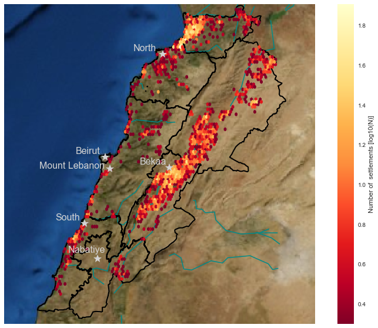

```python
fig = plt.figure(figsize=(14,10))
ax = fig.add_subplot(111)
m = Basemap(projection = 'merc',llcrnrlon=lowercorner[1],llcrnrlat=lowercorner[0],urcrnrlon=uppercorner[1],urcrnrlat=uppercorner[0], lat_ts=lowercorner[0], resolution='i',epsg=22770)
#http://server.arcgisonline.com/arcgis/rest/services ESRI_Imagery_World_2D ESRI_StreetMap_World_2D NatGeo_World_Map

m.arcgisimage(service='ESRI_Imagery_World_2D', xpixels = 300, verbose= True)
#m.drawcoastlines(linewidth=2)
#m.drawcountries(linewidth=2,zorder=1)
m.drawrivers(color='darkcyan',linewidth=1.5,zorder=1)

plotvar = df['Number of Ind'].values+df['Number of Ind in SSBs'].values
#plotvar = df['Water Capacity in L'].values
x, y = m(df['Longitude'].values, df['Latitude'].values)

for ii in range(len(labeltext)):
    xlab,ylab = m(labelcoord[ii][0], labelcoord[ii][1])
    m.plot(xlab, ylab, color = 'lightgray', marker = '*', markersize=15,zorder=2)
    plt.annotate(labeltext[ii],xy=(xlab,ylab),xytext=xytexts[ii],textcoords='offset points',fontsize=16,color='lightgray')

# plot a scatter of the concentration of settlements in log scale
m.hexbin(x, y,  gridsize=100, bins = 'log', mincnt=1, cmap=cm.YlOrRd_r,zorder=2); # bins='log' is log colorscale and yellow is highest (http://matplotlib.org/1.2.1/examples/pylab_examples/hexbin_demo.html)
formatter = LogFormatter(10, labelOnlyBase=False) #,norm=matplotlib.colors.LogNorm()
cb = plt.colorbar() #format=formatter
cb.set_label('Number of  settlements [log10(N)]')
m.readshapefile('/Users/Sarine/Documents/Sarine/Other/PythonLearningSideProjects/lebanon-refugee-data/LBN_adm/LBN_adm1', 'areas',linewidth = 2,zorder = 1)
#shapefile data for Lebanon downloaded from: http://www.diva-gis.org/gdata
#m.areas_info contains information about each of the areas defined in shapefile

# #only plot the 6 governorates in magenta:
# for info, shape in zip(m.areas_info, m.areas):
#     if info['NAME_1'] in labeltext:
#         x, y = zip(*shape)
#         m.plot(x, y, marker=None,color='m',zorder = 1)
```

```
http://server.arcgisonline.com/ArcGIS/rest/services/ESRI_Imagery_World_2D/MapServer/export?bbox=71097.4541823,121921.567328,249626.266334,305681.903906&bboxSR=22770&imageSR=22770&size=300,308&dpi=96&format=png32&f=image
http://server.arcgisonline.com/ArcGIS/rest/services/ESRI_Imagery_World_2D/MapServer/export?bbox=71097.4541823,121921.567328,249626.266334,305681.903906&bboxSR=22770&imageSR=22770&size=300,308&dpi=96&format=png32&f=image
```

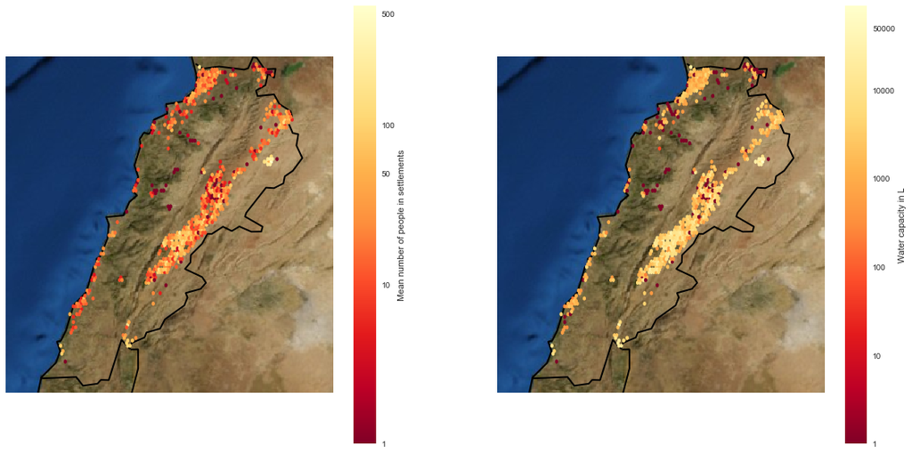

```python
fig = plt.figure(figsize=(20,10))
ax = fig.add_subplot(121)
m = Basemap(projection = 'merc',llcrnrlon=lowercorner[1],llcrnrlat=lowercorner[0],urcrnrlon=uppercorner[1],urcrnrlat=uppercorner[0], lat_ts=lowercorner[0], resolution='i',epsg=22770)
#http://server.arcgisonline.com/arcgis/rest/services

m.arcgisimage(service='ESRI_Imagery_World_2D', xpixels = 300, verbose= True)
m.drawcoastlines(linewidth=2)
m.drawcountries(linewidth=2,zorder=1)

plotvar = df['Number of Ind'].values+df['Number of Ind in SSBs'].values
#plotvar = df['Water Capacity in L'].values
x, y = m(df['Longitude'].values, df['Latitude'].values)
m.hexbin(x, y, C=plotvar, reduce_C_function = np.mean, gridsize=100,  mincnt=1, cmap=cm.YlOrRd_r,zorder=2,norm=matplotlib.colors.LogNorm()); # bins='log' is log colorscale and yellow is highest (http://matplotlib.org/1.2.1/examples/pylab_examples/hexbin_demo.html)
formatter = LogFormatter(10, labelOnlyBase=False) #,norm=matplotlib.colors.LogNorm()
cb = plt.colorbar(format=formatter) #format=formatter
cb.set_ticks([1,10,50,100,500], update_ticks=True)
cb.set_ticklabels(['1','10','50','100','500'], update_ticks=True)
cb.set_label('Mean number of people in settlements')

ax1 = fig.add_subplot(122)
m1 = Basemap(projection = 'merc',llcrnrlon=lowercorner[1],llcrnrlat=lowercorner[0],urcrnrlon=uppercorner[1],urcrnrlat=uppercorner[0], lat_ts=lowercorner[0], resolution='i',epsg=22770)
#http://server.arcgisonline.com/arcgis/rest/services

m1.arcgisimage(service='ESRI_Imagery_World_2D', xpixels = 300, verbose= True)
m1.drawcoastlines(linewidth=2)
m1.drawcountries(linewidth=2,zorder=1)

#plotvar = df['Number of Ind'].values+df['Number of Ind in SSBs'].values
plotvar = df['Water Capacity in L'].values
x, y = m1(df['Longitude'].values, df['Latitude'].values)
m1.hexbin(x, y, C=plotvar, reduce_C_function = np.mean, gridsize=100,  mincnt=1, cmap=cm.YlOrRd_r,zorder=2,norm=matplotlib.colors.LogNorm()); # bins='log' is log colorscale and yellow is highest (http://matplotlib.org/1.2.1/examples/pylab_examples/hexbin_demo.html)
formatter = LogFormatter(10, labelOnlyBase=False) #,norm=matplotlib.colors.LogNorm()
cb = plt.colorbar() #format=formatter
cb.set_ticks([1,10,100,1000,10000,50000], update_ticks=True)
cb.set_ticklabels(['1','10','100','1000','10000','50000'], update_ticks=True)
cb.set_label('Water capacity in L')
```

```python
df.describe()
```

|  | Latitude | Longitude | Number of Tents | Number of Ind | Number of Latrines | Water Capacity in L | Number of SSBs | Number of Ind in SSBs |
| --- | --- | --- | --- | --- | --- | --- | --- | --- |
| count | 6271.000000 | 6271.000000 | 6271.000000 | 6271.000000 | 6271.000000 | 6271.000000 | 6271.000000 | 6271.000000 |
| mean | 34.080139 | 35.987557 | 6.635784 | 37.739117 | 4.133472 | 5097.768777 | 0.424494 | 2.300112 |
| std | 0.362258 | 0.242058 | 15.178345 | 86.767902 | 11.484913 | 12533.038592 | 2.045963 | 10.640577 |
| min | 33.180279 | 35.215012 | 0.000000 | 0.000000 | 0.000000 | 0.000000 | 0.000000 | 0.000000 |
| 25% | 33.796799 | 35.884750 | 0.000000 | 0.000000 | 0.000000 | 0.000000 | 0.000000 | 0.000000 |
| 50% | 34.013199 | 35.997532 | 2.000000 | 11.000000 | 1.000000 | 1000.000000 | 0.000000 | 0.000000 |
| 75% | 34.475367 | 36.087624 | 6.000000 | 33.000000 | 3.000000 | 4000.000000 | 0.000000 | 0.000000 |
| max | 34.669540 | 36.557499 | 244.000000 | 1205.000000 | 224.000000 | 182000.000000 | 63.000000 | 269.000000 |

# Exploration

- Can we predict from location data, water capacity, etc. if the **Status** is *Active* or *Less than 4*?
- Remove *Inactive*, *Erroneous* and *Not Willing*; set *Less than 4* to 0, and *Active* to 1
- Possible features to explore: **Number of Ind** (range?), **Water Capacity in L** (range), **Waste Disposal**, **Waste Water Disposal**, **Number of Latrines**, **District** or **Governorate**, Length of site creation, **Number of SSBs**, **Type of Water Source**, **Type of Contract**, **Type of Internet Connection**.

```python
#drop Inactive, Erroneous and Not Willing rows from Status:
df=df[~df['Status'].isin(["Inactive"])].reset_index(drop=True)
df=df[~df['Status'].isin(["Erroneous"])].reset_index(drop=True)
df=df[~df['Status'].isin(["Not Willing"])].reset_index(drop=True)
```

```python
# map Status onto 0/1:
df['Status'] = df['Status'].map( {'Active': 1, 'Less than 4': 0} ).astype(int)
df['Status'].value_counts()
```

```
1    2273
0    2100
Name: Status, dtype: int64
```

# Missing values

- Type of Water Source has 63 missing values
- Waste Disposal has 66 missing values
- Waste Water Disposal has 152 missing values
- Type of Contract has 99 missing values
- Type of Internet Connection has 450 missing values

```python
df['Type of Water Source'].value_counts().sum()
```

```
4310
```

```python
df['Waste Disposal'].value_counts().sum()
```

```
4307
```

```python
df['Waste Water Disposal'].value_counts().sum()
```

```
4221
```

```python
df['Type of Contract'].value_counts().sum()
```

```
4274
```

```python
df['Type of Internet Connection'].value_counts().sum()
```

```
3923
```

```python
#Drop NAN in all of the above (later: can use the median to replace):
df = df.dropna(axis=0,subset=['Type of Water Source'],how='all')
df = df.dropna(axis=0,subset=['Waste Disposal'],how='all')
df = df.dropna(axis=0,subset=['Waste Water Disposal'],how='all')
df = df.dropna(axis=0,subset=['Type of Contract'],how='all')
df = df.dropna(axis=0,subset=['Type of Internet Connection'],how='all')
df = df.reset_index(drop=True)
```

# Some visualization

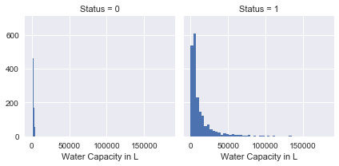

```python
g = sns.FacetGrid(df, col='Status')
g.map(plt.hist, 'Water Capacity in L', bins=50)
```

Water capacity close to 0 in Less than 4 category.

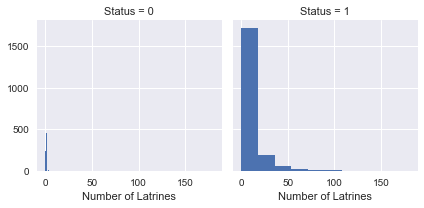

```python
g = sns.FacetGrid(df, col='Status')
g.map(plt.hist, 'Number of Latrines', bins=10)
```

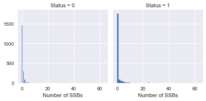

```python
g = sns.FacetGrid(df, col='Status')
g.map(plt.hist, 'Number of SSBs', bins=50)
```

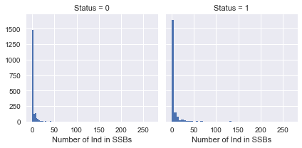

```python
g = sns.FacetGrid(df, col='Status')
g.map(plt.hist, 'Number of Ind in SSBs', bins=50)
```

```python
# map Waste Disposal onto 1, 2, or 3 (lump Bury it with Dump it outside the camp):
df['Waste Disposal'] = df['Waste Disposal'].map( {'Municipality Collection': 1, 'Burn it': 2, 'Dump it outside the camp': 3, 'Burry it': 3} ).astype(int)
df.head()
```

|  | Pcode | Pcode Name | Governorate | District | Cadaster | Local Name | Latitude | Longitude | Shelter Type | Status | ... | Water Capacity in L | Number of SSBs | Number of Ind in SSBs | Type of Water Source | Waste Disposal | Waste Water Disposal | Type of Contract | Type of Internet Connection | Consultation Fee for PHC (3000/5000) | Free Vaccination for Children under 12 |
| --- | --- | --- | --- | --- | --- | --- | --- | --- | --- | --- | --- | --- | --- | --- | --- | --- | --- | --- | --- | --- | --- |
| 0 | 10650-01-001 | Achrafieh fonci�re 001 | Beirut | Beirut | Achrafieh fonci�re | Adleye | 33.877880 | 35.523529 | IS- Informal Settlement | 1 | ... | 0 | 2 | 10 | Water Trucking | 1 | Cesspit | Verbal | Wifi / local Internet service provider | No | No |
| 1 | 21133-01-001 | Furn Ech-Chebbak 001 | Mount Lebanon | Baabda | Furn Ech-Chebbak | furn el chebak | 33.872261 | 35.529671 | IS- Informal Settlement | 0 | ... | 0 | 1 | 6 | Borehole | 1 | Open pit | Verbal | Mobile network - 3G / 4G | Yes | No |
| 2 | 22111-01-001 | Bourj Hammoud 001 | Mount Lebanon | El Metn | Bourj Hammoud | Bourj Hammoud | 33.898899 | 35.547779 | IS- Informal Settlement | 0 | ... | 0 | 0 | 0 | Water Network | 1 | Open pit | Verbal | Mobile network - 3G / 4G | No | No |
| 3 | 22111-01-002 | Bourj Hammoud 002 | Mount Lebanon | El Metn | Bourj Hammoud | Nabaa 1 | 33.886700 | 35.541401 | IS- Informal Settlement | 0 | ... | 0 | 1 | 1 | Water Network | 1 | Municipality sewer network / treated | Verbal | Mobile network - 3G / 4G | No | No |
| 4 | 22155-01-001 | Sinn El-Fil 001 | Mount Lebanon | El Metn | Sinn El-Fil | Sin El Fil | 33.865669 | 35.532650 | IS- Informal Settlement | 0 | ... | 2000 | 0 | 0 | Borehole | 1 | Cesspit | Verbal | Mobile network - 3G / 4G | Yes | Yes |

5 rows × 28 columns

```python
df['Waste Water Disposal'].value_counts()
```

```
Direct discharge to environment             2118
Cesspit                                      809
Open pit                                     427
Holding tank                                 374
Municipality sewer network / not treated     102
Storm water channel                           38
Septic tank                                   22
Municipality sewer network / treated          17
Irrigation canal                              16
Name: Waste Water Disposal, dtype: int64
```

```python
df['Waste Water Disposal'] = df['Waste Water Disposal'].replace(['Storm water channel', 'Septic tank','Municipality sewer network / treated',\
                                                                 'Irrigation canal'], 'Rare')
df['Waste Water Disposal'].value_counts()
```

```
Direct discharge to environment             2118
Cesspit                                      809
Open pit                                     427
Holding tank                                 374
Municipality sewer network / not treated     102
Rare                                          93
Name: Waste Water Disposal, dtype: int64
```

```python
# map Waste Water Disposal into 1, 2, 3, 4, or 5:
df['Waste Water Disposal'] = df['Waste Water Disposal'].map( {'Direct discharge to environment': 1, 'Cesspit': 2, 'Open pit': 3, 'Holding tank': 4, 'Municipality sewer network / not treated': 5, 'Rare': 6} ).astype(int)
df['Waste Water Disposal'].value_counts()
```

```
1    2118
2     809
3     427
4     374
5     102
6      93
Name: Waste Water Disposal, dtype: int64
```

```python
df[['Governorate', 'Status']].groupby(['Governorate'], as_index=False).mean().sort_values(by='Status', ascending=False)
#do not take Governorate as feature?
```

|  | Governorate | Status |
| --- | --- | --- |
| 0 | Beirut | 1.000000 |
| 3 | Nabatiye | 0.736842 |
| 1 | Bekaa | 0.538492 |
| 4 | North | 0.510818 |
| 5 | South | 0.267081 |
| 2 | Mount Lebanon | 0.223140 |

```python
# map Waste Water Disposal into 1, 2, 3, 4, or 5:
df['Governorate'] = df['Governorate'].map( {'Bekaa': 1, 'North': 2, 'South': 3, 'Mount Lebanon': 4, 'Nabatiye': 5, 'Beirut': 6} ).astype(int)
df['Governorate'].value_counts()
```

```
1    2520
2    1063
3     161
4     121
5      57
6       1
Name: Governorate, dtype: int64
```

```python
df[['District', 'Status']].groupby(['District'], as_index=False).mean().sort_values(by='Status', ascending=False)
#do not take District as feature
```

|  | District | Status |
| --- | --- | --- |
| 6 | Beirut | 1.000000 |
| 15 | Marjaayoun | 0.738095 |
| 9 | Hasbaiya | 0.733333 |
| 19 | Sour | 0.714286 |
| 1 | Aley | 0.666667 |
| 22 | Zahle | 0.572519 |
| 10 | Hermel | 0.563636 |
| 0 | Akkar | 0.543307 |
| 3 | Baalbek | 0.542644 |
| 16 | Minieh-Danieh | 0.487047 |
| 14 | Koura | 0.469388 |
| 21 | West Bekaa | 0.455128 |
| 17 | Rachiaya | 0.363636 |
| 20 | Tripoli | 0.333333 |
| 7 | Chouf | 0.226415 |
| 23 | Zgharta | 0.225806 |
| 18 | Saida | 0.225352 |
| 11 | Jezzine | 0.200000 |
| 4 | Batroun | 0.150000 |
| 8 | El Metn | 0.142857 |
| 12 | Jubail | 0.125000 |
| 13 | Kasrouane | 0.068966 |
| 5 | Bcharre | 0.000000 |
| 2 | Baabda | 0.000000 |

```python
df[['Waste Disposal', 'Status']].groupby(['Waste Disposal'], as_index=False).mean().sort_values(by='Status', ascending=False)
#do not take Waste Disposal as feature
```

|  | Waste Disposal | Status |
| --- | --- | --- |
| 0 | 1 | 0.550831 |
| 2 | 3 | 0.528409 |
| 1 | 2 | 0.438193 |

```python
df[['Waste Water Disposal', 'Status']].groupby(['Waste Water Disposal'], as_index=False).mean().sort_values(by='Status', ascending=False)
#take Waste Water Disposal as feature?
```

|  | Waste Water Disposal | Status |
| --- | --- | --- |
| 3 | 4 | 0.713904 |
| 5 | 6 | 0.580645 |
| 4 | 5 | 0.558824 |
| 1 | 2 | 0.543881 |
| 0 | 1 | 0.498111 |
| 2 | 3 | 0.327869 |

```python
df['Type of Water Source'].value_counts()
```

```
Water Trucking    1773
Borehole          1615
Water Network      334
Spring              72
Well                65
Others              43
River               21
Name: Type of Water Source, dtype: int64
```

```python
df['Type of Water Source'] = df['Type of Water Source'].replace(['Spring', 'Well','Others',\
                                                                 'River'], 'Rare')
```

```python
df[['Type of Water Source', 'Status']].groupby(['Type of Water Source'], as_index=False).mean().sort_values(by='Status', ascending=False)
#we *could* take this one as a feature
```

|  | Type of Water Source | Status |
| --- | --- | --- |
| 3 | Water Trucking | 0.637902 |
| 0 | Borehole | 0.422910 |
| 2 | Water Network | 0.410180 |
| 1 | Rare | 0.308458 |

```python
# map Type of Water Source into 1, 2, 3, or 4:
df['Type of Water Source'] = df['Type of Water Source'].map( {'Water Trucking': 1, 'Borehole': 2, 'Water Network': 3, 'Rare': 4} ).astype(int)
df['Type of Water Source'].value_counts()
```

```
1    1773
2    1615
3     334
4     201
Name: Type of Water Source, dtype: int64
```

```python
df['Type of Contract'].value_counts()
```

```
Verbal     2595
None       1237
Written      91
Name: Type of Contract, dtype: int64
```

```python
df[['Type of Contract', 'Status']].groupby(['Type of Contract'], as_index=False).mean().sort_values(by='Status', ascending=False)
# this is a good feature
```

|  | Type of Contract | Status |
| --- | --- | --- |
| 2 | Written | 0.857143 |
| 1 | Verbal | 0.561850 |
| 0 | None | 0.385610 |

```python
# map Type of Contract into 1, 2, or 3:
df['Type of Contract'] = df['Type of Contract'].map( {'Verbal': 1, 'None': 2, 'Written': 3} ).astype(int)
df['Type of Contract'].value_counts()
```

```
1    2595
2    1237
3      91
Name: Type of Contract, dtype: int64
```

```python
df['Type of Internet Connection'].value_counts()
```

```
Mobile network - 3G / 4G                   2835
Wifi  / local Internet service provider     871
No Internet access                          217
Name: Type of Internet Connection, dtype: int64
```

```python
df[['Type of Internet Connection', 'Status']].groupby(['Type of Internet Connection'], as_index=False).mean().sort_values(by='Status', ascending=False)
#possible feature
```

|  | Type of Internet Connection | Status |
| --- | --- | --- |
| 2 | Wifi / local Internet service provider | 0.812859 |
| 0 | Mobile network - 3G / 4G | 0.443034 |
| 1 | No Internet access | 0.225806 |

```python
# map Type of Internet Connection into 1, 2, or 3:
df['Type of Internet Connection'] = df['Type of Internet Connection'].map( {'Mobile network - 3G / 4G': 1, 'Wifi  / local Internet service provider': 2, 'No Internet access': 3} ).astype(int)
df['Type of Internet Connection'].value_counts()
```

```
1    2835
2     871
3     217
Name: Type of Internet Connection, dtype: int64
```

```python
df[['Consultation Fee for PHC (3000/5000)', 'Status']].groupby(['Consultation Fee for PHC (3000/5000)'], as_index=False).mean().sort_values(by='Status', ascending=False)
#not a good feature
```

|  | Consultation Fee for PHC (3000/5000) | Status |
| --- | --- | --- |
| 1 | Yes | 0.547416 |
| 0 | No | 0.468198 |

```python
df[['Free Vaccination for Children under 12', 'Status']].groupby(['Free Vaccination for Children under 12'], as_index=False).mean().sort_values(by='Status', ascending=False)
#not a good feature
```

|  | Free Vaccination for Children under 12 | Status |
| --- | --- | --- |
| 1 | Yes | 0.553311 |
| 0 | No | 0.427200 |

```python
df['LatrinesBand'] = pd.qcut(df['Number of Latrines'], 4)
df[['LatrinesBand', 'Status']].groupby(['LatrinesBand'], as_index=False).mean().sort_values(by='LatrinesBand', ascending=True)
```

|  | LatrinesBand | Status |
| --- | --- | --- |
| 0 | [0, 1] | 0.119174 |
| 1 | (1, 2] | 0.351156 |
| 2 | (2, 5] | 0.837709 |
| 3 | (5, 180] | 0.997755 |

```python
df.loc[df['Number of Latrines'] <= 1, 'LatrinesBandNum'] = 0
df.loc[(df['Number of Latrines'] > 1) & (df['Number of Latrines'] <= 2), 'LatrinesBandNum'] = 1
df.loc[(df['Number of Latrines'] > 2) & (df['Number of Latrines'] <= 5), 'LatrinesBandNum']   = 2
df.loc[ df['Number of Latrines'] > 5, 'LatrinesBandNum'] = 3
df['LatrinesBandNum'] = df['LatrinesBandNum'].astype(int)
df = df.drop(['LatrinesBand'], axis=1)
df.head()
```

|  | Pcode | Pcode Name | Governorate | District | Cadaster | Local Name | Latitude | Longitude | Shelter Type | Status | ... | Number of SSBs | Number of Ind in SSBs | Type of Water Source | Waste Disposal | Waste Water Disposal | Type of Contract | Type of Internet Connection | Consultation Fee for PHC (3000/5000) | Free Vaccination for Children under 12 | LatrinesBandNum |
| --- | --- | --- | --- | --- | --- | --- | --- | --- | --- | --- | --- | --- | --- | --- | --- | --- | --- | --- | --- | --- | --- |
| 0 | 10650-01-001 | Achrafieh fonci�re 001 | 6 | Beirut | Achrafieh fonci�re | Adleye | 33.877880 | 35.523529 | IS- Informal Settlement | 1 | ... | 2 | 10 | 1 | 1 | 2 | 1 | 2 | No | No | 0 |
| 1 | 21133-01-001 | Furn Ech-Chebbak 001 | 4 | Baabda | Furn Ech-Chebbak | furn el chebak | 33.872261 | 35.529671 | IS- Informal Settlement | 0 | ... | 1 | 6 | 2 | 1 | 3 | 1 | 1 | Yes | No | 0 |
| 2 | 22111-01-001 | Bourj Hammoud 001 | 4 | El Metn | Bourj Hammoud | Bourj Hammoud | 33.898899 | 35.547779 | IS- Informal Settlement | 0 | ... | 0 | 0 | 3 | 1 | 3 | 1 | 1 | No | No | 0 |
| 3 | 22111-01-002 | Bourj Hammoud 002 | 4 | El Metn | Bourj Hammoud | Nabaa 1 | 33.886700 | 35.541401 | IS- Informal Settlement | 0 | ... | 1 | 1 | 3 | 1 | 6 | 1 | 1 | No | No | 0 |
| 4 | 22155-01-001 | Sinn El-Fil 001 | 4 | El Metn | Sinn El-Fil | Sin El Fil | 33.865669 | 35.532650 | IS- Informal Settlement | 0 | ... | 0 | 0 | 2 | 1 | 2 | 1 | 1 | Yes | Yes | 0 |

5 rows × 29 columns

```python
df['WaterBand'] = pd.qcut(df['Water Capacity in L'], 4)
df[['WaterBand', 'Status']].groupby(['WaterBand'], as_index=False).mean().sort_values(by='WaterBand', ascending=True)
```

|  | WaterBand | Status |
| --- | --- | --- |
| 0 | [0, 1000] | 0.117089 |
| 1 | (1000, 2500] | 0.272468 |
| 2 | (2500, 7000] | 0.743542 |
| 3 | (7000, 182000] | 0.993135 |

```python
df.loc[df['Water Capacity in L'] <= 1000, 'WaterBandNum'] = 0
df.loc[(df['Water Capacity in L'] > 1000) & (df['Water Capacity in L'] <= 2500), 'WaterBandNum'] = 1
df.loc[(df['Water Capacity in L'] > 2500) & (df['Water Capacity in L'] <= 7000), 'WaterBandNum']   = 2
df.loc[ df['Water Capacity in L'] > 7000, 'WaterBandNum'] = 3
df['WaterBandNum'] = df['WaterBandNum'].astype(int)
df = df.drop(['WaterBand'], axis=1)
df.head()
```

|  | Pcode | Pcode Name | Governorate | District | Cadaster | Local Name | Latitude | Longitude | Shelter Type | Status | ... | Number of Ind in SSBs | Type of Water Source | Waste Disposal | Waste Water Disposal | Type of Contract | Type of Internet Connection | Consultation Fee for PHC (3000/5000) | Free Vaccination for Children under 12 | LatrinesBandNum | WaterBandNum |
| --- | --- | --- | --- | --- | --- | --- | --- | --- | --- | --- | --- | --- | --- | --- | --- | --- | --- | --- | --- | --- | --- |
| 0 | 10650-01-001 | Achrafieh fonci�re 001 | 6 | Beirut | Achrafieh fonci�re | Adleye | 33.877880 | 35.523529 | IS- Informal Settlement | 1 | ... | 10 | 1 | 1 | 2 | 1 | 2 | No | No | 0 | 0 |
| 1 | 21133-01-001 | Furn Ech-Chebbak 001 | 4 | Baabda | Furn Ech-Chebbak | furn el chebak | 33.872261 | 35.529671 | IS- Informal Settlement | 0 | ... | 6 | 2 | 1 | 3 | 1 | 1 | Yes | No | 0 | 0 |
| 2 | 22111-01-001 | Bourj Hammoud 001 | 4 | El Metn | Bourj Hammoud | Bourj Hammoud | 33.898899 | 35.547779 | IS- Informal Settlement | 0 | ... | 0 | 3 | 1 | 3 | 1 | 1 | No | No | 0 | 0 |
| 3 | 22111-01-002 | Bourj Hammoud 002 | 4 | El Metn | Bourj Hammoud | Nabaa 1 | 33.886700 | 35.541401 | IS- Informal Settlement | 0 | ... | 1 | 3 | 1 | 6 | 1 | 1 | No | No | 0 | 0 |
| 4 | 22155-01-001 | Sinn El-Fil 001 | 4 | El Metn | Sinn El-Fil | Sin El Fil | 33.865669 | 35.532650 | IS- Informal Settlement | 0 | ... | 0 | 2 | 1 | 2 | 1 | 1 | Yes | Yes | 0 | 1 |

5 rows × 30 columns

Features to keep : **Water Capacity in L** (range), **Waste Water Disposal**(maybe), **Number of Latrines**, **Type of Water Source**, **Type of Contract**, **Type of Internet Connection**.

```python
df1 = df[['Status','Waste Water Disposal','Type of Water Source', 'Type of Contract','Type of Internet Connection','LatrinesBandNum','WaterBandNum','Governorate']]
df1.head()
```

|  | Status | Waste Water Disposal | Type of Water Source | Type of Contract | Type of Internet Connection | LatrinesBandNum | WaterBandNum | Governorate |
| --- | --- | --- | --- | --- | --- | --- | --- | --- |
| 0 | 1 | 2 | 1 | 1 | 2 | 0 | 0 | 6 |
| 1 | 0 | 3 | 2 | 1 | 1 | 0 | 0 | 4 |
| 2 | 0 | 3 | 3 | 1 | 1 | 0 | 0 | 4 |
| 3 | 0 | 6 | 3 | 1 | 1 | 0 | 0 | 4 |
| 4 | 0 | 2 | 2 | 1 | 1 | 0 | 1 | 4 |

# Machine Learning

```python
df_x = df1.iloc[:,1:] #all the data except labels
df_y = df1.iloc[:,0] #the labels
x_train,x_test,y_train,y_test = train_test_split(df_x,df_y,test_size=0.2,random_state = 4)
```

```python
# Decision Tree
decision_tree = DecisionTreeClassifier()
decision_tree.fit(x_train, y_train)
y_pred = decision_tree.predict(x_test)
acc_decision_tree = round(decision_tree.score(x_train, y_train) * 100, 2)
acc_decision_tree
```

```
91.01
```

```python
# k-Nearest Neighbors
knn = KNeighborsClassifier(n_neighbors = 3)
knn.fit(x_train, y_train)
y_pred = knn.predict(x_test)
acc_knn = round(knn.score(x_train, y_train) * 100, 2)
acc_knn
```

```
88.62
```

```python
# Random Forest
random_forest = RandomForestClassifier(n_estimators=100)
RF_fit = random_forest.fit(x_train, y_train)
#y_pred = random_forest.predict(x_test)
y_pred = RF_fit.predict(x_test)
random_forest.score(x_train, y_train)
acc_random_forest = round(random_forest.score(x_train, y_train) * 100, 2)
acc_random_forest
```

```
91.01
```

```python
#CV
scores = cross_val_score(random_forest, x_train, y_train, cv=10) #,scoring='f1_macro'
print("Accuracy: %0.2f (+/- %0.2f)" % (scores.mean(), scores.std() * 2))
```

```
Accuracy: 0.86 (+/- 0.03)
```

```python
from sklearn import preprocessing
X_train, X_test, y_train, y_test = train_test_split(df_x, df_y, test_size=0.4, random_state=0)
scaler = preprocessing.StandardScaler().fit(X_train)
X_train_transformed = scaler.transform(X_train)
#clf = SVC(C=1).fit(X_train_transformed, y_train)
clf = random_forest.fit(X_train_transformed, y_train)
X_test_transformed = scaler.transform(X_test)
clf.score(X_test_transformed, y_test)
```

```
0.84777070063694271
```

```python
from sklearn.pipeline import make_pipeline
clf = make_pipeline(preprocessing.StandardScaler(), SVC(C=1))
cross_val_score(clf, df_x, df_y, cv=10)
```

```
array([ 0.76081425,  0.78117048,  0.81679389,  0.86734694,  0.89030612,
        0.92857143,  0.90816327,  0.87755102,  0.90306122,  0.82397959])
```

```python
from sklearn.model_selection import cross_val_predict
from sklearn import metrics
predicted = cross_val_predict(clf, df_x, df_y, cv=10)
metrics.accuracy_score(df_y, predicted)
```

```
0.85572266122865159
```

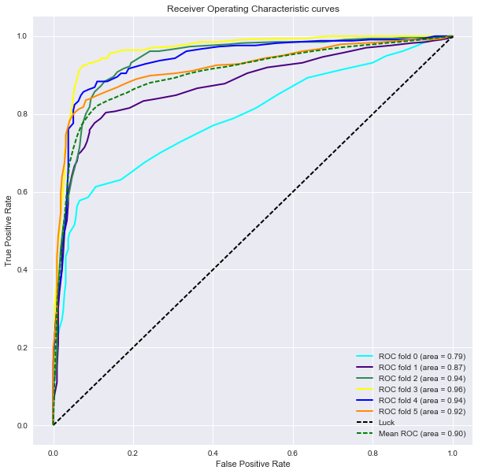

```python
from scipy import interp
from itertools import cycle

from sklearn import svm, datasets
from sklearn.metrics import roc_curve, auc
from sklearn.model_selection import StratifiedKFold

fig = plt.figure(figsize=(10,10))

X = df_x
y = df_y

n_samples, n_features = X.shape

# Add noisy features
random_state = np.random.RandomState(0)
X = np.c_[X, random_state.randn(n_samples, 200 * n_features)]

# Run classifier with cross-validation and plot ROC curves
cv = StratifiedKFold(n_splits=6)
#classifier = svm.SVC(kernel='linear', probability=True, random_state=random_state)
classifier = RandomForestClassifier(n_estimators=100, random_state=random_state)
mean_tpr = 0.0
mean_fpr = np.linspace(0, 1, 100)

colors = cycle(['cyan', 'indigo', 'seagreen', 'yellow', 'blue', 'darkorange'])
lw = 2

i = 0
for (train, test), color in zip(cv.split(X, y), colors):
    probas_ = classifier.fit(X[train], y[train]).predict_proba(X[test])
    # Compute ROC curve and area under the curve
    fpr, tpr, thresholds = roc_curve(y[test], probas_[:, 1])
    mean_tpr += interp(mean_fpr, fpr, tpr)
    mean_tpr[0] = 0.0
    roc_auc = auc(fpr, tpr)
    plt.plot(fpr, tpr, lw=lw, color=color,
             label='ROC fold %d (area = %0.2f)' % (i, roc_auc))

    i += 1
plt.plot([0, 1], [0, 1], linestyle='--', lw=lw, color='k',
         label='Luck')

mean_tpr /= cv.get_n_splits(X, y)
mean_tpr[-1] = 1.0
mean_auc = auc(mean_fpr, mean_tpr)
plt.plot(mean_fpr, mean_tpr, color='g', linestyle='--',
         label='Mean ROC (area = %0.2f)' % mean_auc, lw=lw)

plt.xlim([-0.05, 1.05])
plt.ylim([-0.05, 1.05])
plt.xlabel('False Positive Rate')
plt.ylabel('True Positive Rate')
plt.title('Receiver Operating Characteristic curves')
plt.legend(loc="lower right")
plt.show()
```

# Feature importance

The plot below suggests that two features, **Number of Latrines** and **Water Capacity in L**, are informative in this classification task.

```
                       Feature  Correlation
4              LatrinesBandNum     0.419568
5                 WaterBandNum     0.344770
0         Waste Water Disposal     0.056305
1         Type of Water Source     0.054792
6                  Governorate     0.052668
3  Type of Internet Connection     0.045927
2             Type of Contract     0.025970
```

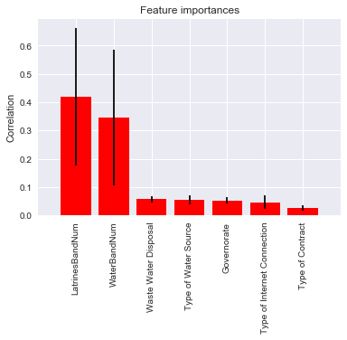

```python
coeff_df = pd.DataFrame(df1.columns.delete(0))
coeff_df.columns = ['Feature']
coeff_df["Correlation"] = pd.Series(random_forest.feature_importances_)

print coeff_df.sort_values(by='Correlation', ascending=False)

importances = random_forest.feature_importances_
std = np.std([tree.feature_importances_ for tree in random_forest.estimators_],
             axis=0)
indices = np.argsort(importances)[::-1]

# # Print the feature ranking
# print("Feature ranking:")

# for f in range(x_train.shape[1]):
#     print("%d. feature %d (%f)" % (f + 1, indices[f], importances[indices[f]]))

# Plot the feature importances of the forest
plt.figure()
plt.title("Feature importances")
plt.bar(range(x_train.shape[1]), importances[indices],
       color="r", yerr=std[indices], align="center")
plt.xticks(range(x_train.shape[1]), x_train.columns[indices].values, rotation='vertical')
plt.xlim([-1, x_train.shape[1]])
plt.ylabel('Correlation')
plt.show()
```